# Procesamiento del Lenguaje Natural

## Licenciatura en Ciencias de la Computación

### Proyecto Final: Análisis de Sentimientos en tweets sobre el gobierno mexicano

Profesora: Olivia Gutú

Integrantes: Adrian L. Soto T. M. Fernanda Domínguez A.

En esta libreta analizaremos y experimentaremos con la base de datos de tweets obtenidos a través de la API de Twitter en la que aportaron todos los compañeros del curso, donde todos los tweets están relacionados con el actual gobierno federal mexicano.

Para construir esta base de datos los estudiantes nos repartimos los días de la semana para consultar los tweets referentes al gobierno por medio de multiples **keywords** relacionadas, de manera que los tweets contienen al menos uno, y posteriormente se clasificaron de la siguiente forma:

0: Liberal - A favor del gobierno actual

1: Conservador - En contra del gobierno actual

2: Neutral - No expresa su posición política

Empezaremos importando todos los módulos que necesitaremos.

```python
import pandas as pd
import nltk
import random
import numpy as np
import re
import tweepy
from nltk.tokenize import TweetTokenizer
from sklearn import model_selection
from sklearn.feature_extraction.text import TfidfVectorizer
from sklearn.model_selection import train_test_split
from sklearn.metrics import accuracy_score
from sklearn.naive_bayes import MultinomialNB
from sklearn.linear_model import LogisticRegression
from sklearn.linear_model import LinearRegression
from sklearn.ensemble import RandomForestClassifier
from sklearn.svm import SVC
from sklearn.model_selection import cross_val_score
from sklearn.metrics import confusion_matrix
from sklearn.metrics import plot_confusion_matrix
import matplotlib.pyplot as plt
import plotly.express as px

nltk.download('punkt')
```

```
True
```

Leemos nuestra base de datos de tweets

```python
tweets = pd.read_csv('tweets_base.csv', encoding ='utf-8', index_col=0)
tweets.head(2)
```

|  | created_at | id | user id | full_text | localidad | retweet_count | favorite_count | clasification | tidy_text | user_name |
| --- | --- | --- | --- | --- | --- | --- | --- | --- | --- | --- |
| 0 | 12/10/2020 01:31 | 1.320000e+18 | 9.884670e+17 | Slim es de los principales beneficiados por AM... | Xochimilco, Distrito Federal | 0 | 0 | 1.0 | slim principales beneficiados amlo siempre mas... | NaN |
| 1 | 12/10/2020 02:30 | 1.320000e+18 | 1.147230e+18 | ¡ESTO NO LO VISTE DE @lopezobrador_ EN VERDAD... | Aquí! en mi México Querido. | 0 | 0 | 0.0 | viste @lopezobrador_ verdad ll0ro dar mensaje ... | NaN |

Nos deshacemos de los tweets con etiqueta 'No Aplica' (los que no están relacionados pero por alguna razón salieron en las consultas)

```python
tweets = tweets.drop(tweets[tweets.clasification == 3].index)
```

Hacemos limpieza de Símbolos y enlaces

```python
def rm_links(tweet):
    tweet = re.sub(r'^https?:\/\/.*[\r\n]*', '', tweet, flags=re.MULTILINE)
    tweet = tweet.replace('.','').replace(':','').replace(';','').replace('-','').replace('&','').replace('$','').replace('/','')
    return tweet

tweets['tidy_text'] = tweets['tidy_text'].apply(rm_links)
```

Creamos una columna donde agregamos las cuentas que mencionan los tweets para próximas estadísticas.

```python
def get_mentions(t):
  return(re.findall(r"\@(\w+)", t))
tweets['mentions'] = tweets['tidy_text'].apply(get_mentions)
```

Creamos una columna donde agregamos los hashtags que se mencionan en los tweets.

```python
# Creación de columna de hashtags
def get_hashtags(t):
  return(re.findall(r"#(\w+)", t))
tweets['hashtags'] = tweets['tidy_text'].apply(get_hashtags)
```

Tokenizamos el texto ya normalizado.

```python
tt = TweetTokenizer()
tweets['tokens'] = tweets['tidy_text'].apply(tt.tokenize)
tweets['tokens'] = tweets.tokens.apply(lambda x: np.array(x))
tweets.head(2)
```

|  | created_at | id | user id | full_text | localidad | retweet_count | favorite_count | clasification | tidy_text | user_name | mentions | hashtags | tokens |
| --- | --- | --- | --- | --- | --- | --- | --- | --- | --- | --- | --- | --- | --- |
| 0 | 12/10/2020 01:31 | 1.320000e+18 | 9.884670e+17 | Slim es de los principales beneficiados por AM... | Xochimilco, Distrito Federal | 0 | 0 | 1.0 | slim principales beneficiados amlo siempre mas... | NaN | [] | [] | [slim, principales, beneficiados, amlo, siempr... |
| 1 | 12/10/2020 02:30 | 1.320000e+18 | 1.147230e+18 | ¡ESTO NO LO VISTE DE @lopezobrador_ EN VERDAD... | Aquí! en mi México Querido. | 0 | 0 | 0.0 | viste @lopezobrador_ verdad ll0ro dar mensaje ... | NaN | [lopezobrador_, fernandeznorona] | [amlo] | [viste, @lopezobrador_, verdad, ll0ro, dar, me... |

```python
def clasify_string(c):
  switch = {
      0: 'lib',
      1: 'con',
      2: 'neu'
  }
  return switch.get(c)
tweets['clasification_string'] = tweets['clasification'].apply(clasify_string)
```

Para usar algún modelo de clasificación, primero necesitamos extraer las características de los textos, vectorizarlos. Para esto utilizamos el vectorizador tfidf, este sirve para determinar que tan relevante es una palabra para un documento en una colección. Consideramos que es mejor opción que solo usar el conteo.

```python
def get_feature_vector(train_fit):
    vectorizer = TfidfVectorizer(max_features=12000)
    vectorizer.fit(train_fit)
    return vectorizer
tf_vector = get_feature_vector(np.array(tweets['tidy_text']).ravel())
X = tf_vector.transform(np.array(tweets['tidy_text']).ravel())
y = np.array(tweets['clasification_string']).ravel()
```

Ya que tenemos nuestros datos vectorizados, los partimos en los de entrenamiento y los de prueba, y estamos listps para entrenar un clasificador con Regresión Logística

```python
X_train, X_test, y_train, y_test = train_test_split(X, y, test_size=0.2, random_state=30)
LR_model = LogisticRegression(C=2.0, max_iter=200)
LR_model.fit(X_train, y_train)
```

```
LogisticRegression(C=2.0, max_iter=200)
```

Ya que se entrenó sigue probarlo con nuestro conjunto X_test, y_test

```python
y_predict_lr = LR_model.predict(X_test)
print(accuracy_score(y_test, y_predict_lr))
```

```
0.6360294117647058
```

Vamos a ver si con un clasificador Naive Bayes multinomial podemos mejorar ese score.

```python
NB_model = MultinomialNB(alpha=0.4)
NB_model.fit(X_train, y_train)
```

```
MultinomialNB(alpha=0.4)
```

```python
y_predict_lr = NB_model.predict(X_test)
print(accuracy_score(y_test, y_predict_lr))
```

```
0.6352941176470588
```

```python
this_scores = cross_val_score(NB_model, X, y, n_jobs=1)
this_scores
```

```
array([0.57352941, 0.55294118, 0.58014706, 0.59264706, 0.55294118])
```

Y calcularemos su matriz de confusión

```
<sklearn.metrics._plot.confusion_matrix.ConfusionMatrixDisplay at 0x7f131d61d4e0>
```

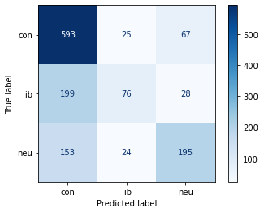

```python
class_names = np.unique(y_test)
plot_confusion_matrix(NB_model, X_test, y_test, display_labels=class_names, cmap=plt.cm.Blues)
```

Ahora intentaremos con un clasificador de bosques aleatorios.

```python
RF_model = RandomForestClassifier(max_depth=2000, min_samples_leaf=3, n_estimators=500)
RF_model.fit(X_train, y_train)
```

```
RandomForestClassifier(max_depth=2000, min_samples_leaf=3, n_estimators=500)
```

```python
y_predict_lr = RF_model.predict(X_test)
print(accuracy_score(y_test, y_predict_lr))
```

```
0.6154411764705883
```

Le daremos una última oportunidad a los datos, ahora con una máquina de vectores de soporte

```python
SVC_model = SVC(C=4, kernel='poly', degree=2, gamma=4)
SVC_model.fit(X_train, y_train)
```

```
SVC(C=4, degree=2, gamma=4, kernel='poly')
```

```python
y_predict_lr = SVC_model.predict(X_test)
print(accuracy_score(y_test, y_predict_lr))
```

```
0.6360294117647058
```

Ahora intentaremos utilizar solo dos categorías (lib, con), a ver si nos ayuda a mejorar el score de nuestro clasificador

```python
df = tweets.loc[tweets['clasification'] < 2]
```

Vectorizamos de nuevo los tweets que formaran parte del desarrollo de los nuevos clasificadores binarios

```python
# Cambiamos a hacer clasificador binario (a favor/en contra)
tf_vector = get_feature_vector(np.array(df['tidy_text']).ravel())
X = tf_vector.transform(np.array(df['tidy_text']).ravel())
y = np.array(df['clasification_string']).ravel()
```

Empezamos con regresión logística de nuevo

```python
# Regresión Logística
X_train, X_test, y_train, y_test = train_test_split(X, y, test_size=0.2, random_state=30)
LR_model = LogisticRegression(C=4, tol=0.001, solver='saga')
LR_model.fit(X_train, y_train)
```

```
LogisticRegression(C=4, solver='saga', tol=0.001)
```

Nos queda un score:

```python
y_predict_lr = LR_model.predict(X_test)
print(accuracy_score(y_test, y_predict_lr))
```

```
0.7148803329864725
```

Ahora intentemos con un bosque aleatorio:

```python
RF_model = RandomForestClassifier()
RF_model.fit(X_train, y_train)
y_predict_lr = RF_model.predict(X_test)
print(accuracy_score(y_test, y_predict_lr))
```

```
0.6940686784599376
```

Una máquina de vectores de soporte para la clasificación binaria

```python
SVC_model = SVC(C=0.5, kernel='sigmoid', degree=2, gamma=2)
SVC_model.fit(X_train, y_train)
y_predict_lr = SVC_model.predict(X_test)
print(accuracy_score(y_test, y_predict_lr))
```

```
0.7221644120707597
```

Este parece ser el mejor score obtenido hasta ahora, por lo que sería bueno aplicar cross validation y sacar su matriz de confusión

```python
this_scores = cross_val_score(SVC_model, X, y, n_jobs=1)
this_scores
```

```
array([0.72216441, 0.68886576, 0.72320499, 0.71458333, 0.66770833])
```

```
<sklearn.metrics._plot.confusion_matrix.ConfusionMatrixDisplay at 0x7f131df816d8>
```

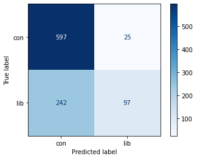

```python
class_names = np.unique(y_test)
plot_confusion_matrix(SVC_model, X_test, y_test, display_labels=class_names, cmap=plt.cm.Blues)
```

# Gráficas

```python
def tuple_list(r, col):
  t = [(i, tweets['clasification_string'][r]) for i in tweets[col][r]]
  return t

def get_graph_df(df, col):
  d = {
    col: [],
    'class': [],
    'count': [],
    'total': []
  }
  for w in df[col].unique():
    w_df = df[df[col] == w]
    #CONSERVADOR
    d[col].append(w)
    d['count'].append(w_df[w_df['class']=='con'].shape[0])
    d['class'].append('con')
    d['total'].append(w_df.shape[0])
    #LIBERAL
    d[col].append(w)
    d['count'].append(w_df[w_df['class']=='lib'].shape[0])
    d['class'].append('lib')
    d['total'].append(w_df.shape[0])
    #NEUTRAL
    d[col].append(w)
    d['count'].append(w_df[w_df['class']=='neu'].shape[0])
    d['class'].append('neu')
    d['total'].append(w_df.shape[0])

  w_df = pd.DataFrame(d)
  w_df = w_df.sort_values(by=['total'], ascending=False)
  w_df = w_df.head(60)
  return w_df
```

Primero graficamos los 20 hashtags más utilizados en los tweets

```python
h = []
for index, row in tweets.iterrows():
    h = h + tuple_list(index, 'hashtags')
hashtags = pd.DataFrame(h, columns=['hashtags', 'class'])
h_df = get_graph_df(hashtags, "hashtags")
fig = px.bar(h_df, x="hashtags", y="count", color="class", title="Los 20 hashtags más utilizados", color_discrete_sequence=["#7570B3", "#666666", "#E6AB02"])
fig.show()
```

[interactive chart not shown]

```python
u = []
for index, row in tweets.iterrows():
    u.append((tweets['user id'][index], tweets['user_name'][index], tweets['clasification_string'][index]))

# DataFrame para análisis de users
users = pd.DataFrame(u, columns=['user_id','username', 'class'])
users.username
users.loc[(pd.isnull(users.username)),'username']='NA'

u_df = get_graph_df(users, "username")
fig = px.bar(u_df, x="username", y="count", color="class", title="Las 20 cuentas que más twittean sobre el gobierno federal", color_discrete_sequence=["#7570B3", "#666666", "#E6AB02"])
fig.show()
```

[interactive chart not shown]

Aquí podemos ver la extraordinaria cifra de tweets NA, NA es el grupo de tweets donde a través de la API de twitter no se pudo encontrar su nombre de usuario, es decir, ese usuario ya no existe. Lo que nos puede dejar pensando que se trata de casos de los famosos "bots" políticos. Curiosamente la mayoria de los tweets que generan estas cuentas NA son en contra del gobierno federal.

```python
m = []
for index, row in tweets.iterrows():
    m = m + tuple_list(index, 'mentions')
mentions = pd.DataFrame(m, columns=['mentions', 'class'])
m_df = get_graph_df(mentions, "mentions")
fig = px.bar(m_df, x="mentions", y="count", color="class", title="Los 20 usuarions más mencionados en tweets", color_discrete_sequence=["#7570B3", "#666666", "#E6AB02"])
fig.show()
```

[interactive chart not shown]